# Tugas Pertemuan 67

Rafi AKbar Wibawa

2023-10-05

```r
library("forecast")
```

```r
library("graphics")
library("TTR")
library("TSA")
library("rio")
library(ggplot2)
library(tsibble)
library(tseries)
library(MASS)
library(dplyr)
library(TTR)
library(forecast)
library(lmtest)
library(orcutt)
library(HoRM)
library(dLagM)
library(dynlm)
library(MLmetrics)
library(car)
library(TSA)
library(aTSA)
```

## Impor Data

```r
data <- import("https://raw.githubusercontent.com/rafi2411/MPDW-STA1341/main/Pertemuan-1/Data/Raw%20Data.csv")
colnames(data) <- c("Waktu", "NO2")
data$Waktu<- ts(data$Waktu,frequency = 24)
Data<- data$NO2
Data <- ts(Data)
```

# Pembagian Data train dan data test

```r
Train <- Data[1:80]
Test <- Data[81:length(Data)]
```

### Plot *Time Series*

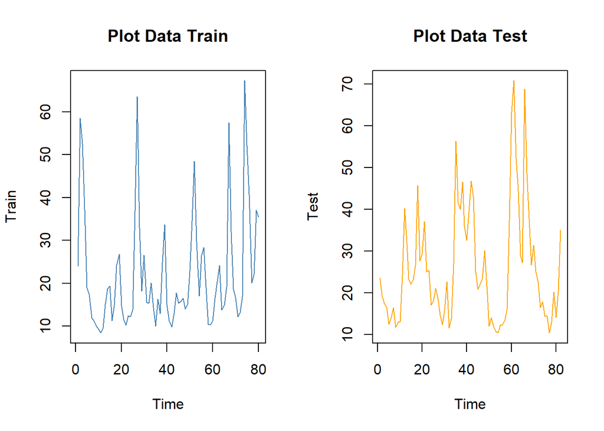

```r
par(mfrow=c(1,2))
plot.ts(Train, main = "Plot Data Train", col = 'steelblue')
plot.ts(Test,main = "Plot Data Test", col = 'orange')
```

Plot deret waktu di atas menunjukkan bahwa data Data stasioner dalam rataan, ditandai dengan data yang menyebar di sekitar nilai tengahnya dan Data tidak stasionerioner dalam ragam, ditandai dengan lebar pita yang cenderung berubah-rubah dengan berpola musiman.

### Plot ACF

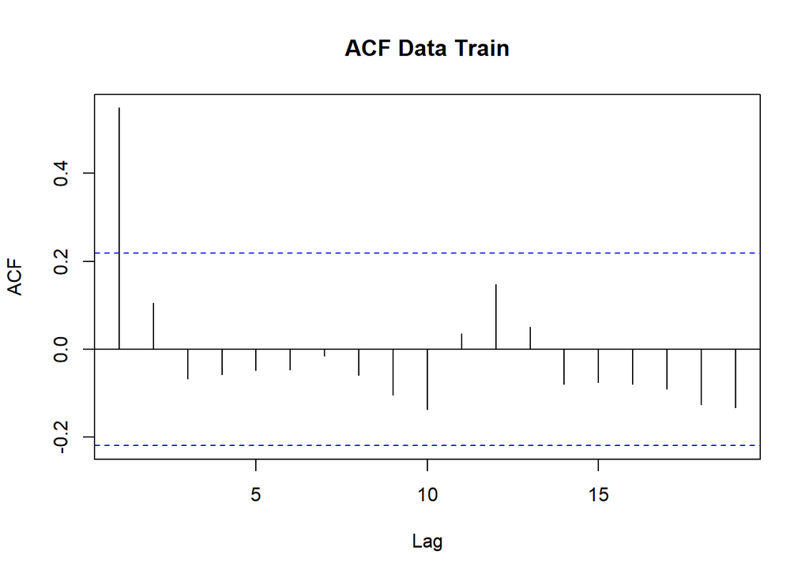

```r
acf(Train, main = "ACF Data Train")
```

### Uji ADF

```r
tseries::adf.test(Train)
```

```
##
##  Augmented Dickey-Fuller Test
##
## data:  Train
## Dickey-Fuller = -4.4439, Lag order = 4, p-value = 0.01
## alternative hypothesis: stationary
```

$H_0$ : Data tidak Dataioner dalam rataan

$H_1$ : Data Dataioner dalam rataan

Berdasarkan uji ADF tersebut, didapat *p-value* sebesar 0.01 yang lebih kecil dari taraf nyata 5% sehingga tolak $H_0$ dan menandakan bahwa data Dataioner dalam rataan. Hal ini sesuai dengan hasil eksplorasi menggunakan plot time series dan plot ACF.

### Plot Box-Cox

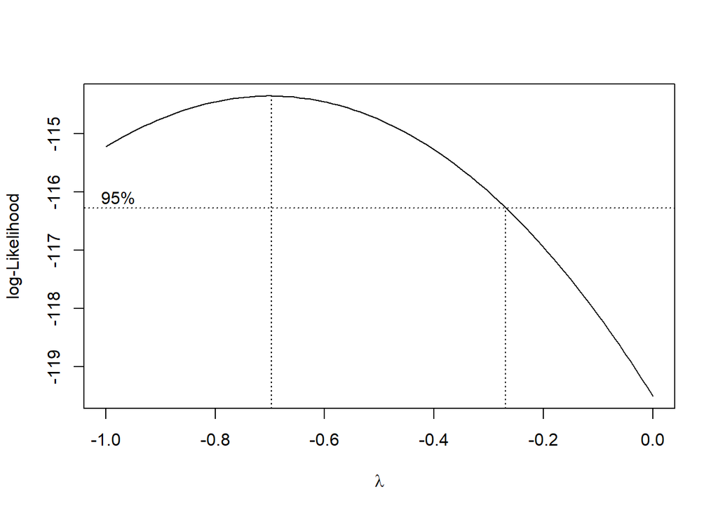

```r
index <- seq(1:length(Train))
bc = boxcox(Train~index, lambda = seq(-1,0,by=0.05))
```

```r
#Nilai Rounded Lambda
lambda <- bc$x[which.max(bc$y)]
lambda
```

```
## [1] -0.6969697
```

```r
#SK
bc$x[bc$y > max(bc$y) - 1/2 * qchisq(.95,1)]
```

```
##  [1] -1.0000000 -0.9898990 -0.9797980 -0.9696970 -0.9595960 -0.9494949
##  [7] -0.9393939 -0.9292929 -0.9191919 -0.9090909 -0.8989899 -0.8888889
## [13] -0.8787879 -0.8686869 -0.8585859 -0.8484848 -0.8383838 -0.8282828
## [19] -0.8181818 -0.8080808 -0.7979798 -0.7878788 -0.7777778 -0.7676768
## [25] -0.7575758 -0.7474747 -0.7373737 -0.7272727 -0.7171717 -0.7070707
## [31] -0.6969697 -0.6868687 -0.6767677 -0.6666667 -0.6565657 -0.6464646
## [37] -0.6363636 -0.6262626 -0.6161616 -0.6060606 -0.5959596 -0.5858586
## [43] -0.5757576 -0.5656566 -0.5555556 -0.5454545 -0.5353535 -0.5252525
## [49] -0.5151515 -0.5050505 -0.4949495 -0.4848485 -0.4747475 -0.4646465
## [55] -0.4545455 -0.4444444 -0.4343434 -0.4242424 -0.4141414 -0.4040404
## [61] -0.3939394 -0.3838384 -0.3737374 -0.3636364 -0.3535354 -0.3434343
## [67] -0.3333333 -0.3232323 -0.3131313 -0.3030303 -0.2929293 -0.2828283
## [73] -0.2727273
```